# Root_Bacteria

Wes Bickford

8/2/2017

# Root Bacteria Analysis

## Rarefaction Curves

These are rarefaction curves for all samples. Samples were rarefied to 483 sequences as that was the lowest number at any site.

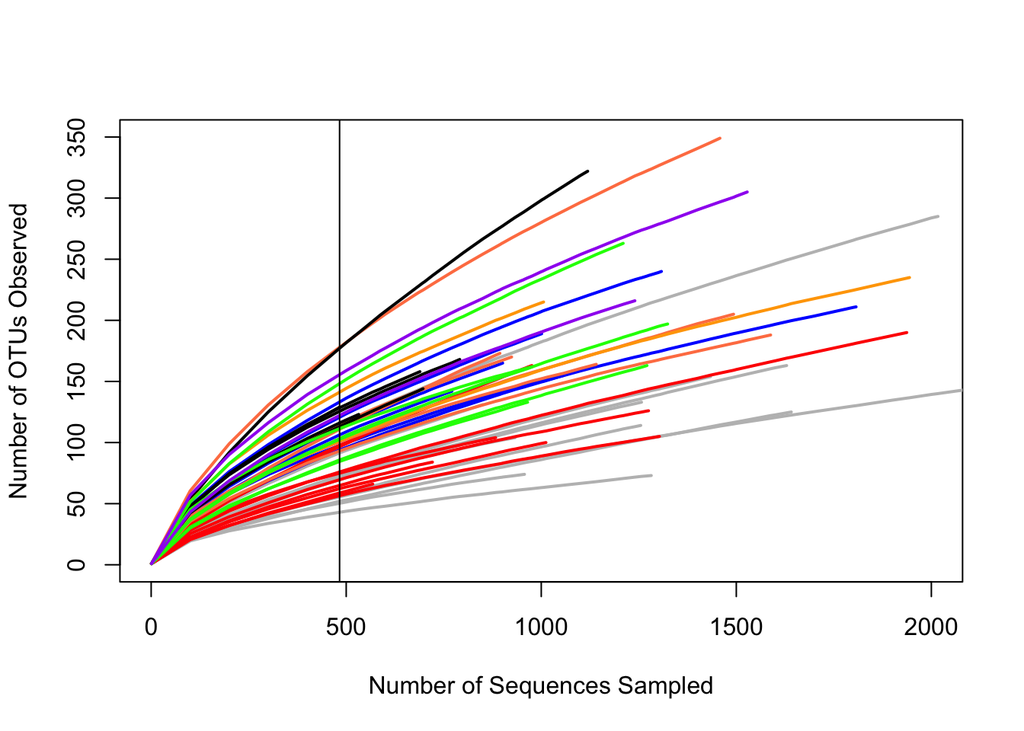

## Alpha Diversity

The following shows shannon diversity by lineage

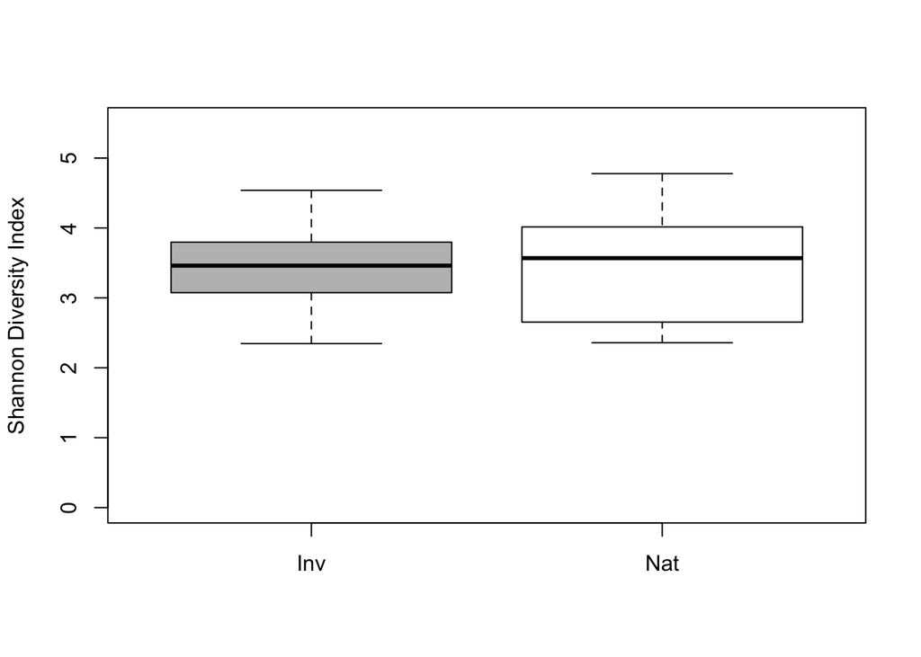

##Alpha Diversity

The following shows shannon diversity by site and lineage

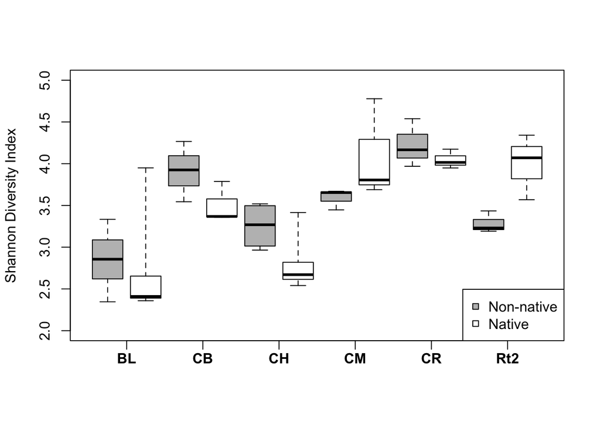

```
##
##  Welch Two Sample t-test
##
## data:  npshannon by Lineage
## t = 0.018836, df = 42.669, p-value = 0.9851
## alternative hypothesis: true difference in means is not equal to 0
## 95 percent confidence interval:
##  -0.3802797  0.3874489
## sample estimates:
## mean in group Inv mean in group Nat
##          3.450302          3.446718
```

## Community Analysis

### PerManova

The following is a PerMANOVA of OTUs by site and Lineage

```
##
## Call:
## adonis(formula = shared ~ Site * Lineage + Sat_lev, data = meta_alpha,      method = "bray")
##
## Permutation: free
## Number of permutations: 999
##
## Terms added sequentially (first to last)
##
##              Df SumsOfSqs MeanSqs F.Model      R2 Pr(>F)
## Site          7    3.2434 0.46334  2.8853 0.31580  0.001 ***
## Lineage       1    0.3213 0.32127  2.0006 0.03128  0.023 *
## Sat_lev       2    0.5818 0.29092  1.8116 0.05665  0.008 **
## Site:Lineage  7    1.1459 0.16370  1.0194 0.11157  0.399
## Residuals    31    4.9781 0.16058         0.48470
## Total        48   10.2705                 1.00000
## ---
## Signif. codes:  0 '***' 0.001 '**' 0.01 '*' 0.05 '.' 0.1 ' ' 1
```

### NMDS

The following is an NMDS (stress = 0.196162) showing Lineage as different shapes and site by color. The ellipses are sd by site.

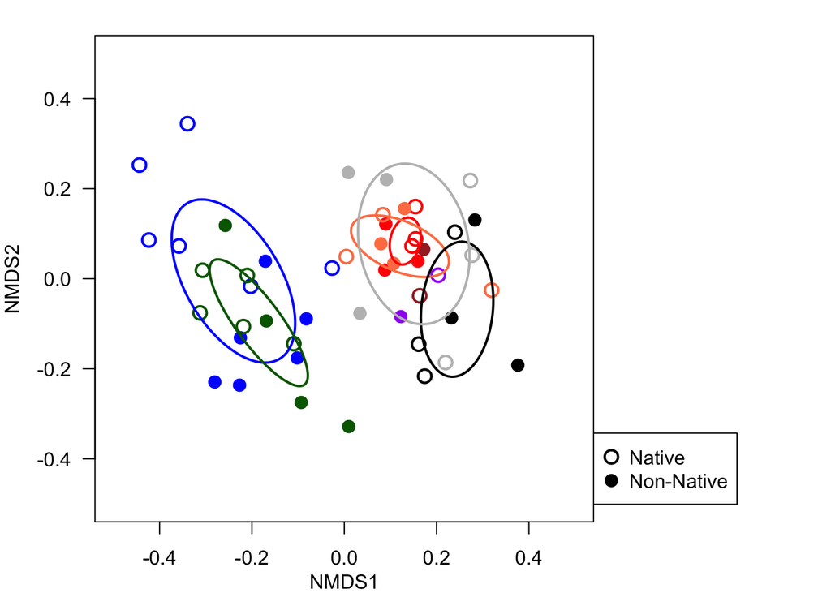

### Remove rare taxa

I removed rare taxa using relative abundance data. Any OTU that made up less than 0.1% of the total sequences was removed. This is more stringent than removing singletons, but ensures that rare taxa are not responsible for site effects. The following are results of a permanova of only abundant taxa by site and lineage.

```
##
## Call:
## adonis(formula = shared_abundant ~ Site * Lineage + Sat_lev,      data = meta_alpha)
##
## Permutation: free
## Number of permutations: 999
##
## Terms added sequentially (first to last)
##
##              Df SumsOfSqs MeanSqs F.Model      R2 Pr(>F)
## Site          7    2.9112 0.41589  3.2780 0.34360  0.001 ***
## Lineage       1    0.2883 0.28833  2.2726 0.03403  0.012 *
## Sat_lev       2    0.4772 0.23862  1.8808 0.05633  0.021 *
## Site:Lineage  7    0.8628 0.12325  0.9715 0.10183  0.527
## Residuals    31    3.9331 0.12688         0.46421
## Total        48    8.4728                 1.00000
## ---
## Signif. codes:  0 '***' 0.001 '**' 0.01 '*' 0.05 '.' 0.1 ' ' 1
```

Removing rare taxa reduced the total OTU number from 1819 to 89

There is still a significant difference in the community using only abundant taxa.

### NMDS with Rare Taxa removed

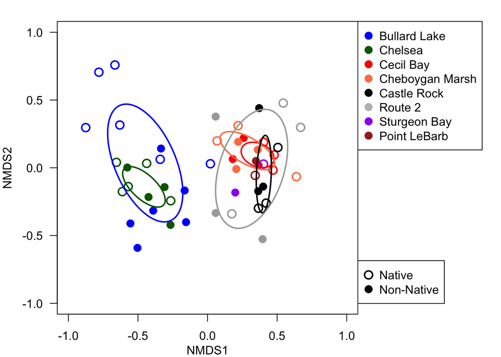

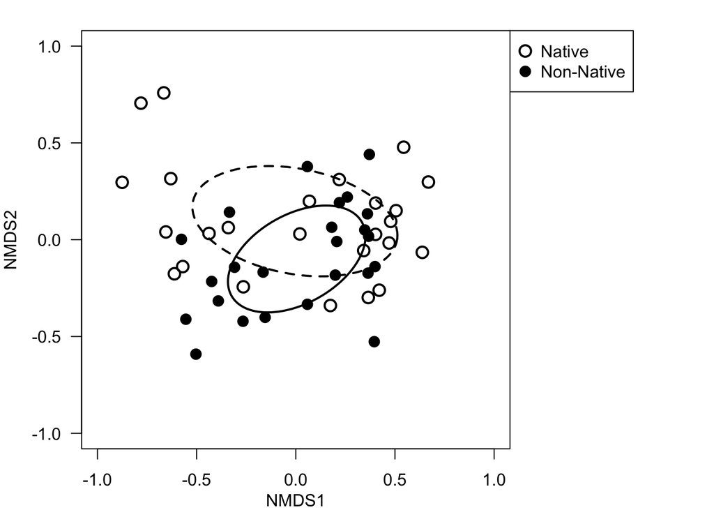

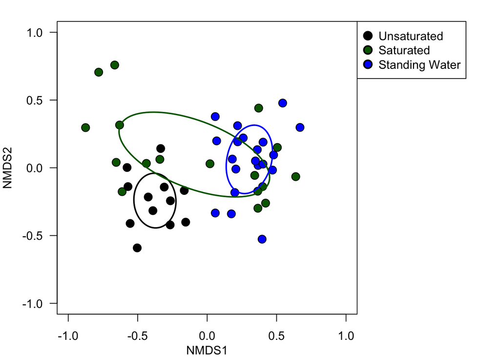

I also performed a Kruskal-Wallace test to see if the relative abundance of any individual taxon differed by site or lineage. All tests were non-significant indicating that no individual otu relative abundances are significantly different by site or lineage

## Taxonomic Analysis

### By Phylum

The following show all bacterial Phyla by relative sequence abundance

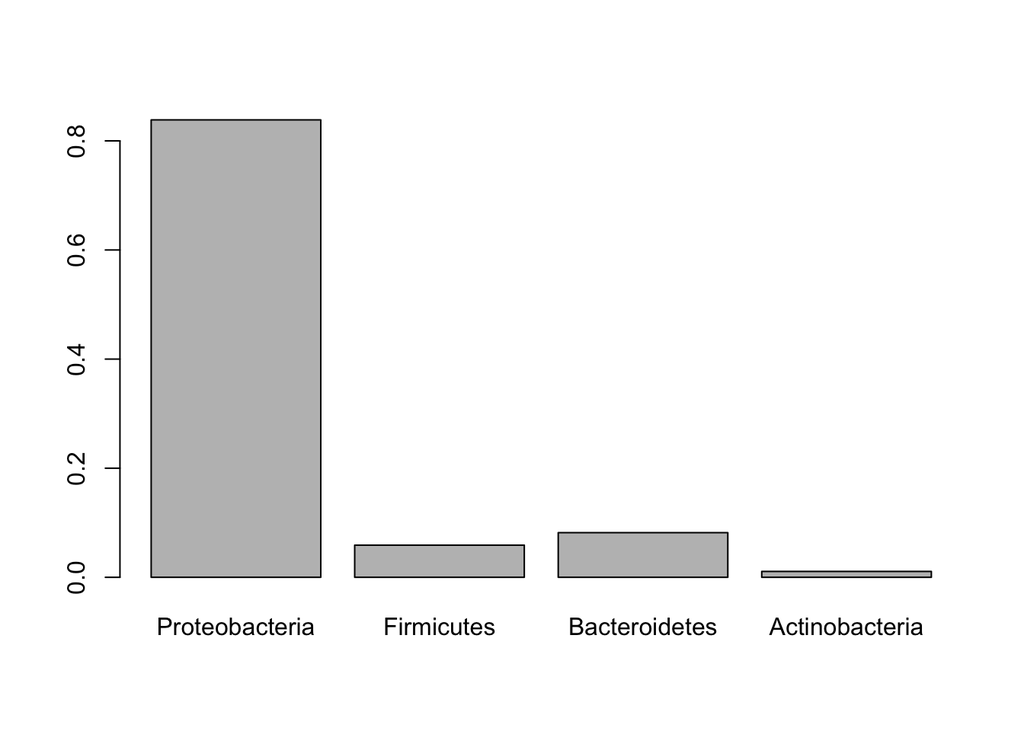

The following show all bacterial Phyla by relative sequence abundance

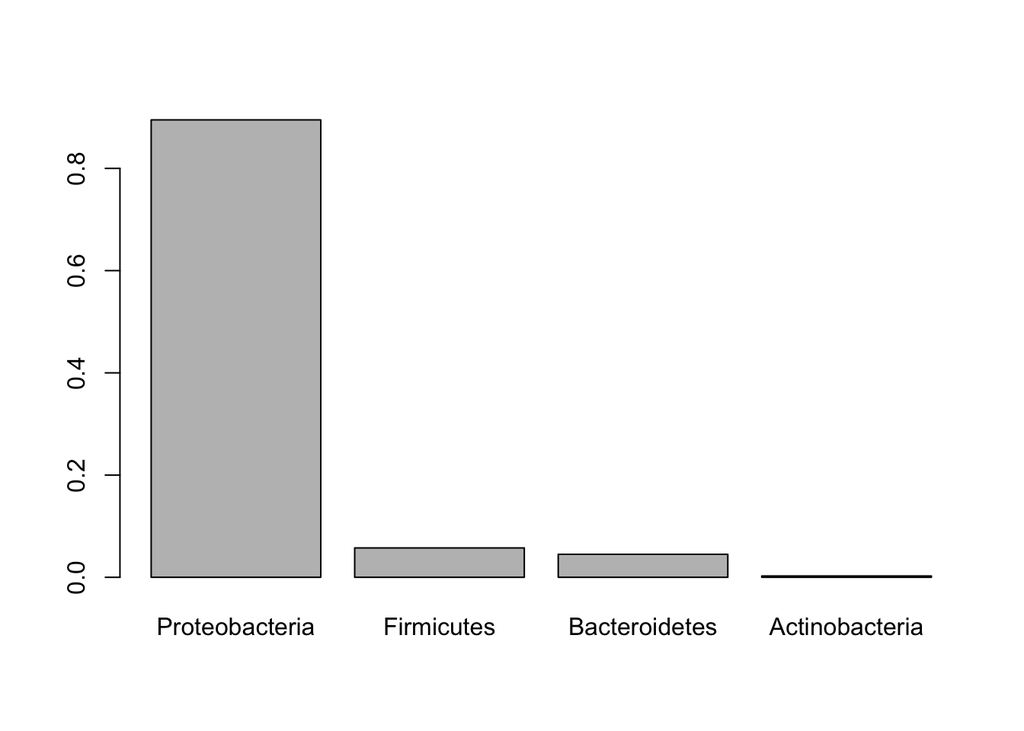

Proteobacteria makes up 89.4932791% of the total sequences!

### By Genus

```
##                   Pseudomonas             Janthinobacterium
##                    0.53517093                    0.05428062
##                     Rhizobium                     Duganella
##                    0.04591179                    0.04332363
##                     Aeromonas                      Rahnella
##                    0.03894891                    0.02902829
## Oxalobacteraceae_unclassified                  Rheinheimera
##                    0.01758544                    0.01673080
##                   Caulobacter   Comamonadaceae_unclassified
##                    0.01564763                    0.01454430
##                       Devosia                 Undibacterium
##                    0.01280573                    0.01105817
##                    Acidovorax                 Asticcacaulis
##                    0.01037106                    0.01019141
```

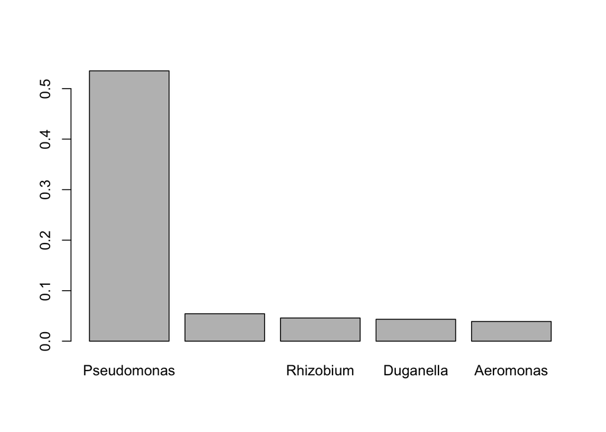

```
##                   Pseudomonas             Janthinobacterium
##                    0.58121438                    0.06029778
##                     Rhizobium                     Duganella
##                    0.04557110                    0.04472203
##                     Aeromonas                      Rahnella
##                    0.04142707                    0.03354832
##                  Rheinheimera                   Caulobacter
##                    0.01872491                    0.01823828
## Oxalobacteraceae_unclassified                       Devosia
##                    0.01592775                    0.01358963
##   Comamonadaceae_unclassified                 Undibacterium
##                    0.01312242                    0.01185670
##                    Acidovorax                    Rhodoferax
##                    0.01091076                    0.01053681
```

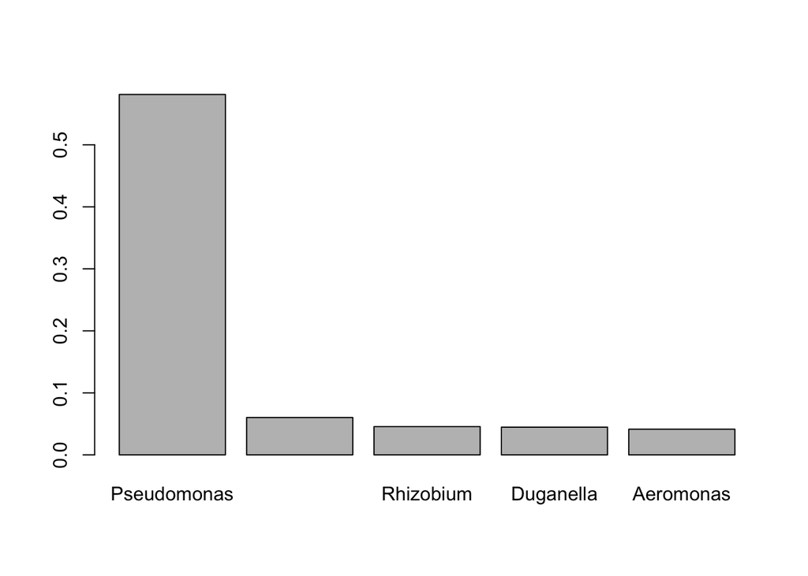

```
## Percentage of OTUs from each Kingdom:
##
## Bacteria
##      100
## Percentage of OTUs from each represented phylum in Bacteria :
##
##                                                                                                       Proteobacteria
##                                                                                                          56.71785029
##                                                                                                        Bacteroidetes
##                                                                                                          19.99360205
##                                                                                                           Firmicutes
##                                                                                                           7.13371721
##                                                                                                       Actinobacteria
##                                                                                                           5.21433141
##                                                                                                      Verrucomicrobia
##                                                                                                           2.07933461
##                                                                                                       Planctomycetes
##                                                                                                           1.95137556
##                                                                                                          Chloroflexi
##                                                                                                           1.79142674
##                                                                                                Bacteria_unclassified
##                                                                                                           0.92770313
##                                                                                                        Acidobacteria
##                                                                                                           0.76775432
##                                                                                                     Saccharibacteria
##                                                                                                           0.73576456
##                                                                                                         Spirochaetae
##                                                                                                           0.73576456
##                                                                                                        Cyanobacteria
##                                                                                                           0.44785669
##                                                                                                      Armatimonadetes
##                                                                                                           0.28790787
##                                                                                                        Parcubacteria
##                                                                                                           0.22392834
##                                                                                                        Fibrobacteres
##                                                                                                           0.19193858
##                                                                                                      Gracilibacteria
##                                                                                                           0.15994882
##                                                                                                          Nitrospirae
##                                                                                                           0.15994882
```

[output cut: 20 more lines]

```
##
## Call:
## adonis(formula = sudo_shared ~ Site * Lineage, data = meta_alpha)
##
## Permutation: free
## Number of permutations: 999
##
## Terms added sequentially (first to last)
##
##              Df SumsOfSqs  MeanSqs F.Model      R2 Pr(>F)
## Site          7    1.8888 0.269832  3.1372 0.33483  0.001 ***
## Lineage       1    0.1831 0.183120  2.1291 0.03246  0.083 .
## Site:Lineage  7    0.7308 0.104407  1.2139 0.12956  0.225
## Residuals    33    2.8383 0.086009         0.50315
## Total        48    5.6411                  1.00000
## ---
## Signif. codes:  0 '***' 0.001 '**' 0.01 '*' 0.05 '.' 0.1 ' ' 1
```

```
##
## Call:
## adonis(formula = sudo_shared_ab ~ Site * Lineage, data = meta_alpha)
##
## Permutation: free
## Number of permutations: 999
##
## Terms added sequentially (first to last)
##
##              Df SumsOfSqs  MeanSqs F.Model      R2 Pr(>F)
## Site          7    1.8111 0.258730  3.2784 0.34339  0.001 ***
## Lineage       1    0.1734 0.173379  2.1969 0.03287  0.096 .
## Site:Lineage  7    0.6854 0.097915  1.2407 0.12995  0.215
## Residuals    33    2.6043 0.078919         0.49378
## Total        48    5.2742                  1.00000
## ---
## Signif. codes:  0 '***' 0.001 '**' 0.01 '*' 0.05 '.' 0.1 ' ' 1
```

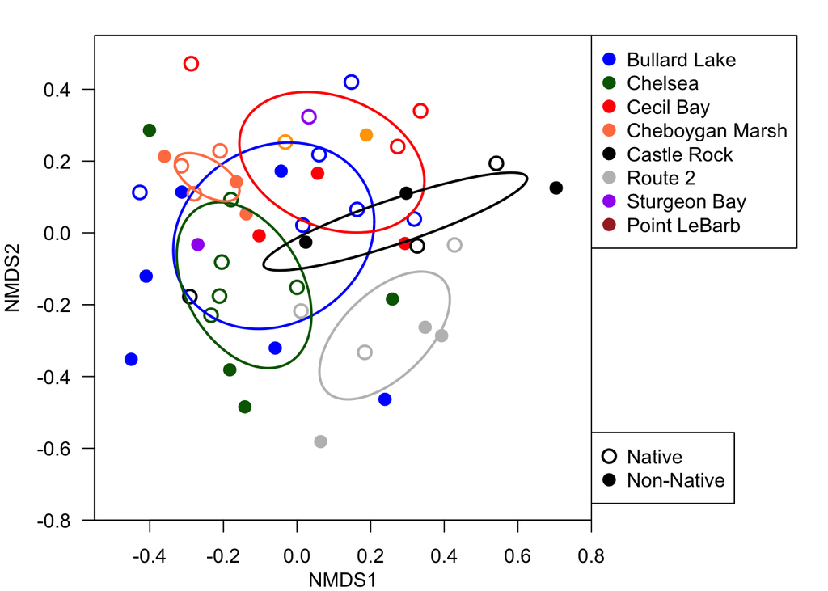

## Nutrients

### Soil Nutrients

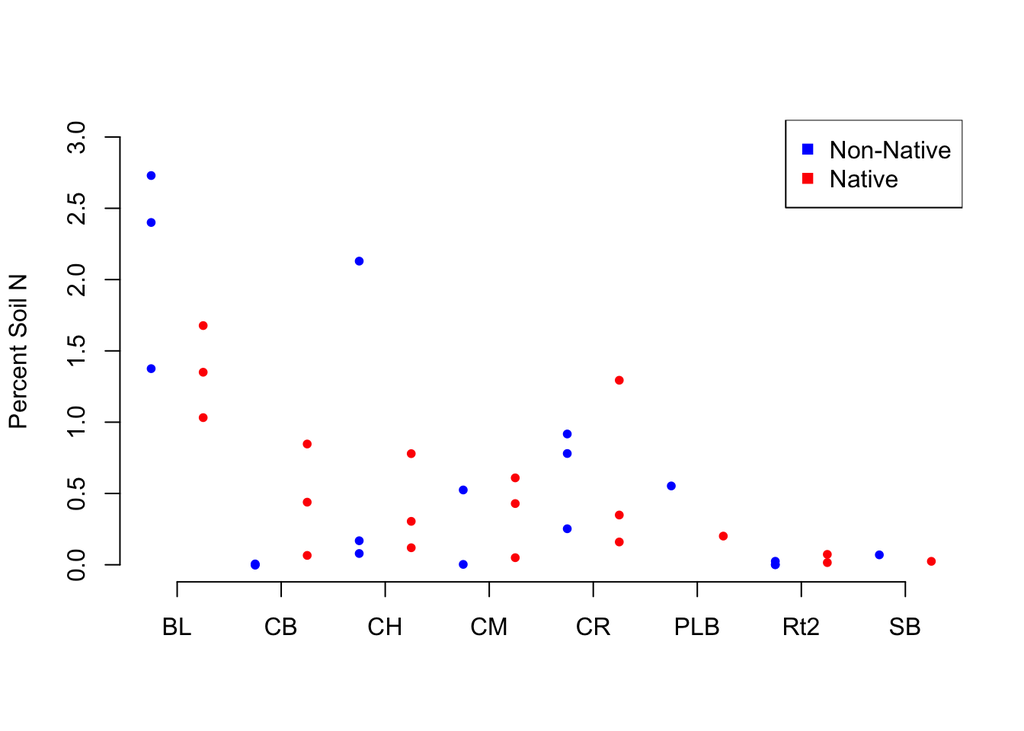

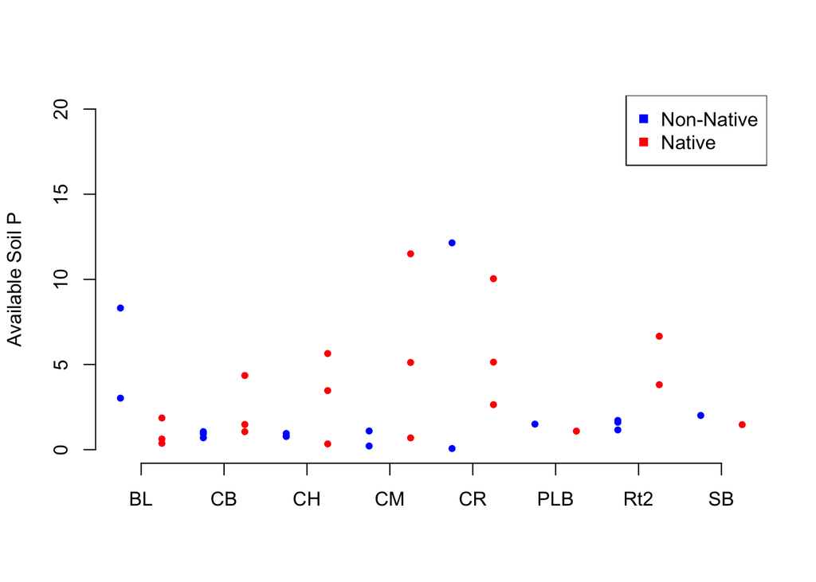

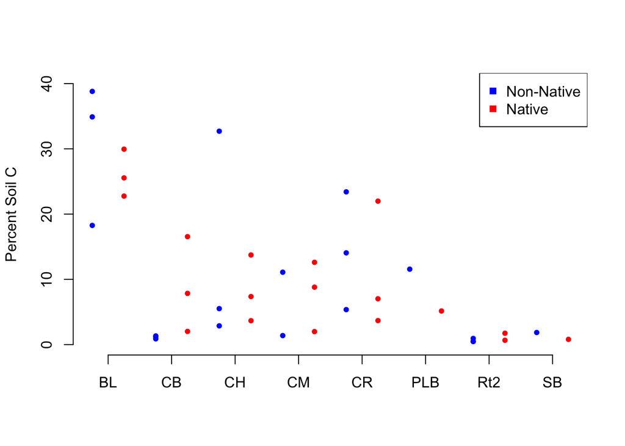

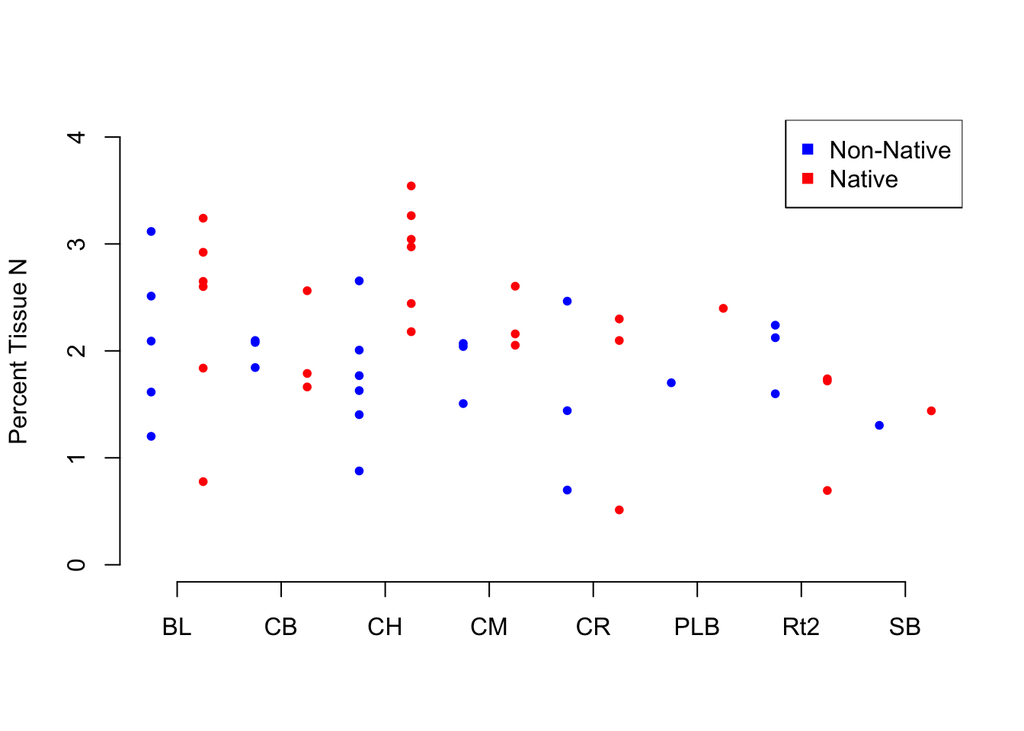

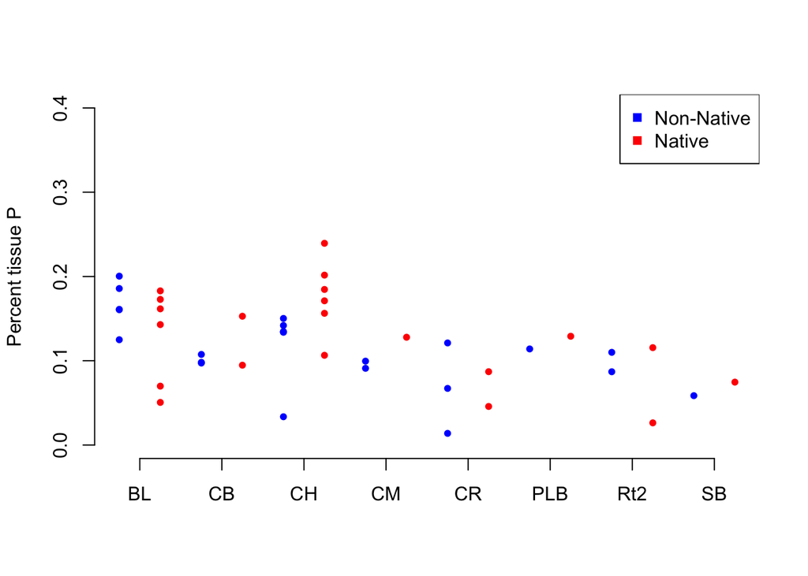

plot NMDS scores against nitrogen content

```
##
## Call:
## lm(formula = ma_finite$X15SoilN ~ NMDS1 * NMDS2)
##
## Coefficients:
## (Intercept)        NMDS1        NMDS2  NMDS1:NMDS2
##      0.6547      -1.7354       0.1027      -2.0280
```

```
##
## Call:
## lm(formula = ma_finite$X15SoilN ~ NMDS1 * NMDS2)
##
## Residuals:
##      Min       1Q   Median       3Q      Max
## -0.89683 -0.44277 -0.07385  0.19998  1.81434
##
## Coefficients:
##             Estimate Std. Error t value Pr(>|t|)
## (Intercept)   0.6547     0.1098   5.960  9.7e-07 ***
## NMDS1        -1.7354     0.5572  -3.114  0.00373 **
## NMDS2         0.1027     0.7841   0.131  0.89659
## NMDS1:NMDS2  -2.0280     3.5922  -0.565  0.57607
## ---
## Signif. codes:  0 '***' 0.001 '**' 0.01 '*' 0.05 '.' 0.1 ' ' 1
##
## Residual standard error: 0.6561 on 34 degrees of freedom
## Multiple R-squared:  0.2292, Adjusted R-squared:  0.1612
## F-statistic:  3.37 on 3 and 34 DF,  p-value: 0.02959
```

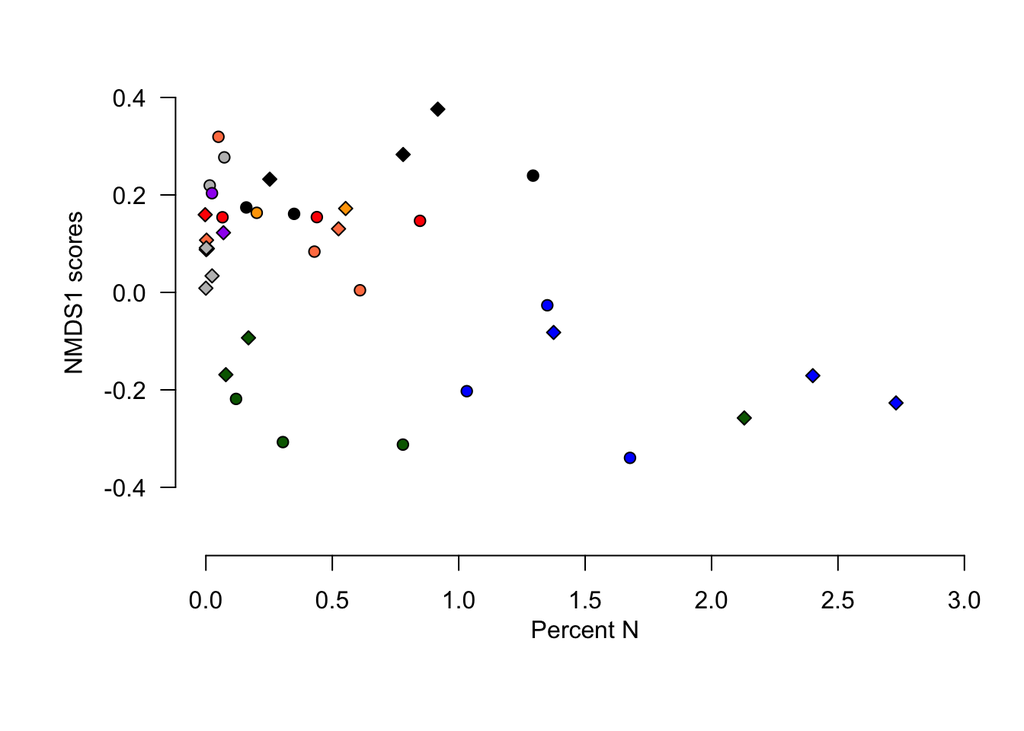

Adding nutrients into PerMANOVA

```
##
## Call:
## adonis(formula = shared_finite ~ X15SoilN * X15SoilP, data = ma_finite,      method = "bray")
##
## Permutation: free
## Number of permutations: 999
##
## Terms added sequentially (first to last)
##
##                   Df SumsOfSqs MeanSqs F.Model      R2 Pr(>F)
## X15SoilN           1    0.4417 0.44174 2.14274 0.05628  0.008 **
## X15SoilP           1    0.1662 0.16620 0.80619 0.02117  0.692
## X15SoilN:X15SoilP  1    0.2324 0.23238 1.12719 0.02960  0.276
## Residuals         34    7.0093 0.20616         0.89295
## Total             37    7.8496                 1.00000
## ---
## Signif. codes:  0 '***' 0.001 '**' 0.01 '*' 0.05 '.' 0.1 ' ' 1
```

```
##
## Call:
## adonis(formula = shared_tisfinite ~ X15TisN * X15TisP, data = tisma_finite,      method = "bray")
##
## Permutation: free
## Number of permutations: 999
##
## Terms added sequentially (first to last)
##
##                 Df SumsOfSqs MeanSqs F.Model      R2 Pr(>F)
## X15TisN          1    0.5104 0.51040 2.58782 0.05999  0.001 ***
## X15TisP          1    0.5144 0.51440 2.60812 0.06047  0.002 **
## X15TisN:X15TisP  1    0.1851 0.18506 0.93828 0.02175  0.499
## Residuals       37    7.2975 0.19723         0.85779
## Total           40    8.5074                 1.00000
## ---
## Signif. codes:  0 '***' 0.001 '**' 0.01 '*' 0.05 '.' 0.1 ' ' 1
```